Note: The precise numbers of articles returned by the different queries can change somewhat over time as it appears the data in the Archive is still subject to revisions.

### Article Search API

Loading packages:

```r
library("httr")
library("jsonlite")
library("tidyverse")
library("dotenv")
```

We are now going to work with a private API, using we will take the New York Times Article Search API as an example. This API allows users to search articles by string and dates, and returns counts of articles and a short description of each article (but not the full text). You can create a new account and obtain a key [here](https://developer.nytimes.com/get-started). Create an `.env` file in your **local** directory, and save your key. Remember, be sure never to display any file publicly, e.g. in a public repo or a private collaborative repo, when it contains an active key!

```r
# read_______(".env")
# apikey <- Sys.____("API_KEY")
#
# # Read the .env file
# dotenv::load_dotenv(".env")  # This loads environment variables from .env

apikey <- Sys.getenv("API_KEY")  # Retrieve API key
print(apikey)  # Check if it's loaded correctly (avoid printing secrets in real use)
```

```
## [1] "ng5PgWgqPoCqorzNRS8cwPPz2KAo1D7S"
```

The first step is to identify the base URL of the endpoint and the parameters that we can use to query the API, for the Article Search API you can find this URL structure [here](https://developer.nytimes.com/docs/articlesearch-product/1/overview). Now we can do a first API call using the **httr** package.

```r
base_url <- "https://api.nytimes.com/svc/search/v2/articlesearch.json"
r <- GET(base_url, query = list(q = "inequality", "api-key" = apikey))
r
```

```
## Response [https://api.nytimes.com/svc/search/v2/articlesearch.json?q=inequality&api-key=ng5PgWgqPoCqorzNRS8cwPPz2KAo1D7S]
##   Date: 2025-03-23 15:28
##   Status: 200
##   Content-Type: application/json
##   Size: 211 kB
```

From the output of the response object which we named `r`, we can see that the query was successful (`Status: 200`), the content is in `json` format, and we can see its size (anything more than `0kb` is what we are looking for).

There are different options how to proceed with this output using the `content` function. We can look at its text (note that as JSON uses a lot of quotation marks, R signals with a forward slash for each of them that they are not the outer quotation marks of the main character/string in R):

```r
substr(content(r, "text", encoding = "UTF-8"), 1, 1000)
```

[output not shown]

Let’s also write it to disk as a JSON file (make sure you have a `data` folder in your working directory):

```r
file_con <- file("data/nyt.json")
writeLines(content(r, "text", encoding = "UTF-8"), con = file_con)
close(file_con)
```

We can also parse the JSON content into a corresponding R object (here a list) to learn more about its structure. We will use these corresponding R objects (mainly lists) in the following for our computations:

```r
# json <- ____(r, "_____")
# class(json)
# ____(json) # list with 3 elements
# json$status # This should be "OK"
# ____(json$response) # the actual data/response in the json object parsed with httr
# length(json$response$docs) # The returned documents (capped at 10)
# json$response$___ # The meta data of the request (hits returns the total number of articles)

json <- content(r, "parsed")  # Extracts the JSON response as a structured list
class(json)
```

```
## [1] "list"
```

```r
length(json)  # List with 3 elements
```

```
## [1] 3
```

```r
json$status  # This should be "OK"
```

```
## [1] "OK"
```

```r
# str(json$response)  # Shows the structure of the response object
# invisible(str(json$response))
names(json$response)
```

```
## [1] "docs" "meta"
```

```r
length(json$response$docs)  # The number of returned documents (default: max 10)
```

```
## [1] 10
```

```r
json$response$meta  # Metadata of the request (e.g., "hits" = total articles available)
```

```
## $hits
## [1] 26995
##
## $offset
## [1] 0
##
## $time
## [1] 41
```

So while the amount of returned documents here is capped at ten, there exists the hits key in the meta data which gives the total amount of articles which contained the keyword. This is every helpful for us and we can use it in a function.

If we check the documentation, we find that we can subset by date with the `begin_date` and `end_date` parameters. Let us see how this works:

```r
r <- GET(base_url, query = list(q = "inequality",
                                "api-key" = apikey,
                                "begin_date" = 20190101,
                                "end_date" = 20191231))
json <- content(r, "parsed")
json$response$meta
```

```
## $hits
## [1] 1463
##
## $offset
## [1] 0
##
## $time
## [1] 36
```

Question: Between these two dates, how many articles in the NYT mentioning “inequality”?

Now imagine we want to look at the evolution of mentions of this word over time. Following the coding practices we introduced earlier, we want to write a function that will take a word and a set of dates as arguments and return the counts of articles:

```r
nyt_count <- function(q, date1, date2) {

  # Get the return of the request
  r <- GET(base_url, query = list(q = q,
                                  "api-key" = apikey,
                                  "begin_date" = date1,
                                  "end_date" = date2))

  # Add a check whether rate limit was hit and retry until status code OK
  while (r$status_code != 200){
    message("Error occured. Retry after 10 seconds..")
    Sys.sleep(10) # Wait 10 seconds
    r <- GET(base_url, query = list(q = q,
                                    "api-key" = apikey,
                                    "begin_date" = date1,
                                    "end_date" = date2))

  }

  # Parse the return into R once no error
  json <- content(r, "parsed")

  # Return the article count
  return(json$response$meta$hits)
}

# Article count for January 2019
nyt_count(q = "inequality", date1 = 20190101, date2 = 20190131)
```

```
## [1] 110
```

We want to run this function multiple times, so let us write another function that helps us do that:

```r
nyt_years_count <- function(q, yearinit, yearend) {

  # Create a sequence of years to loop over and an empty numeric vector
  years <- seq(yearinit, yearend)
  counts <- integer()

  # loop over years
  for (y in years) {

    # Message to track progress
    message(y)

    # Retrieve count
    counts <- c(counts, nyt_count(q = q,
                                  date1 = paste0(y, "0101"),
                                  date2 = paste0(y, "1231")))

    # Wait 6 seconds between requests as only 10 requests per minute allowed
    Sys.sleep(6)

  }
   # Return a dataframe with year and article count
  return(data.frame(year = years, count = counts))
}
```

```r
# Let us see what happens
nyt_years_count(q = "inequality", yearinit = 2019, yearend = 2020)
```

```
## 2019
```

```
## 2020
```

```
##   year count
## 1 2019  1463
## 2 2020  1859
```

```r
counts_inequality <- nyt_years_count(q = "inequality", yearinit = 2015, yearend = 2020)
```

```
## 2015
```

```
## 2016
```

```
## 2017
```

```
## 2018
```

```
## 2019
```

```
## 2020
```

```
## Error occured. Retry after 10 seconds..
## Error occured. Retry after 10 seconds..
## Error occured. Retry after 10 seconds..
```

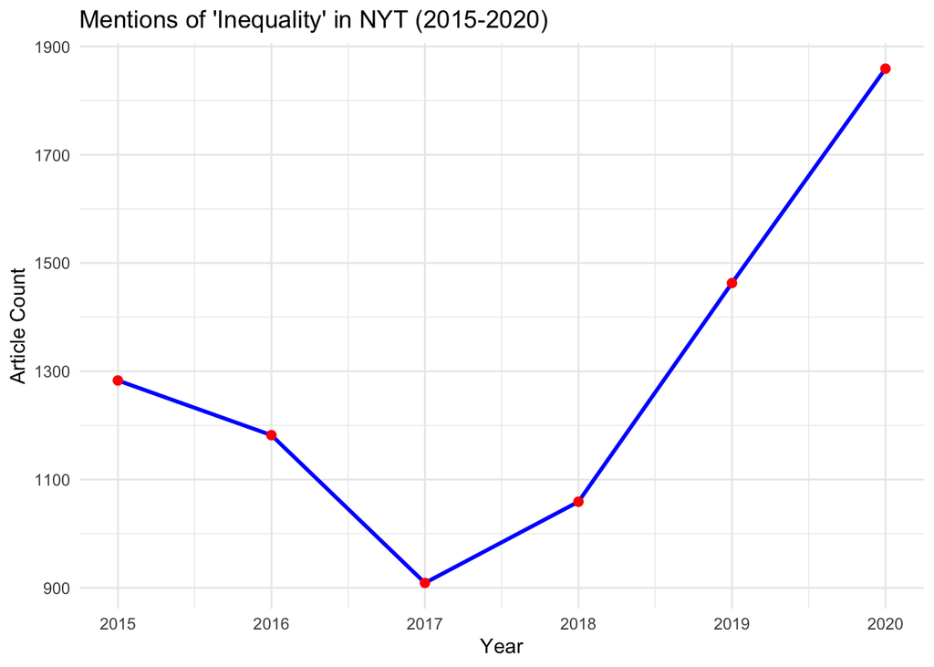

```r
# ggplot() +
#   geom_line(aes(x = 2015:2020, y = counts_inequality)) +
#   labs(title = "Mentions of inequality in the NYT by year",
#        y = "Article count",
#        x = "") +
#   theme_minimal()

ggplot(counts_inequality, aes(x = year, y = count)) +
  geom_line(color = "blue", size = 1) +
  geom_point(color = "red", size = 2) +
  labs(title = "Mentions of 'Inequality' in NYT (2015-2020)",
       y = "Article Count",
       x = "Year") +
  theme_minimal()
```

Note: This output will be somewhat biased by changes in the amount of (print) content. To be more precise, we should divide the time series by the different totals of articles at every point of time (i.e. by the time-series obtained when searching for `""`).

Let us try to improve the function such that it works with any date interval, not just years and such that it returns a data frame:

```r
nyt_dates_count <- function(q, init, end, by){

  # Note that init and end are now date objects and we can create a sequence with them
  dates <- seq(from = as.Date(init), to = as.Date(end), by = by)
  dates <- format(dates, "%Y%m%d") # changing date format to match NYT API date format
  counts <- rep(NA, length(dates) - 1)

  # Loop over periods
  for (i in 1:(length(dates) - 1)) { ## note the -1 here
    # Update to track progress
    message(dates[i])
    # Retrieve count
    counts[i] <- nyt_count(q = q, date1 = dates[i],
                           date2 = dates[i + 1])
    # Wait 6 seconds between requests as only 10 requests per minute allowed
    Sys.sleep(6)
  }

  # Now the function also returns a dataframe with two columns: date & count
  df <- data.frame(date = as.Date(dates[-length(dates)], format = "%Y%m%d"), count = counts)
  return(df)
}
```

```r
counts <- nyt_dates_count(q = "obama", init = "2007-01-01",
                          end = "2012-12-31", by = "month")
```

```
## 20070101
```

```
## 20070201
```

```
## 20070301
```

```
## 20070401
```

```
## 20070501
```

```
## Error occured. Retry after 10 seconds..
## Error occured. Retry after 10 seconds..
```

```
## 20070601
```

```
## 20070701
```

```
## 20070801
```

```
## 20070901
```

```
## 20071001
```

```
## Error occured. Retry after 10 seconds..
## Error occured. Retry after 10 seconds..
## Error occured. Retry after 10 seconds..
```

```
## 20071101
```

```
## 20071201
```

```
## 20080101
```

```
## 20080201
```

```
## 20080301
```

```
## Error occured. Retry after 10 seconds..
## Error occured. Retry after 10 seconds..
## Error occured. Retry after 10 seconds..
```

```
## 20080401
```

```
## 20080501
```

```
## 20080601
```

```
## 20080701
```

```
## 20080801
```

```
## Error occured. Retry after 10 seconds..
## Error occured. Retry after 10 seconds..
## Error occured. Retry after 10 seconds..
```

```
## 20080901
```

```
## 20081001
```

```
## 20081101
```

```
## 20081201
```

```
## 20090101
```

```
## Error occured. Retry after 10 seconds..
## Error occured. Retry after 10 seconds..
```

```
## 20090201
```

```
## 20090301
```

```
## 20090401
```

```
## 20090501
```

```
## 20090601
```

```
## Error occured. Retry after 10 seconds..
## Error occured. Retry after 10 seconds..
## Error occured. Retry after 10 seconds..
```

```
## 20090701
```

```
## 20090801
```

```
## 20090901
```

```
## 20091001
```

```
## 20091101
```

```
## Error occured. Retry after 10 seconds..
## Error occured. Retry after 10 seconds..
## Error occured. Retry after 10 seconds..
```

```
## 20091201
```

```
## 20100101
```

```
## 20100201
```

```
## 20100301
```

```
## 20100401
```

```
## Error occured. Retry after 10 seconds..
## Error occured. Retry after 10 seconds..
## Error occured. Retry after 10 seconds..
```

```
## 20100501
```

```
## 20100601
```

```
## 20100701
```

```
## 20100801
```

```
## 20100901
```

```
## Error occured. Retry after 10 seconds..
## Error occured. Retry after 10 seconds..
```

```
## 20101001
```

```
## 20101101
```

```
## 20101201
```

```
## 20110101
```

```
## 20110201
```

```
## Error occured. Retry after 10 seconds..
## Error occured. Retry after 10 seconds..
## Error occured. Retry after 10 seconds..
```

```
## 20110301
```

```
## 20110401
```

```
## 20110501
```

```
## 20110601
```

```
## 20110701
```

```
## Error occured. Retry after 10 seconds..
## Error occured. Retry after 10 seconds..
## Error occured. Retry after 10 seconds..
```

```
## 20110801
```

```
## 20110901
```

```
## 20111001
```

```
## 20111101
```

```
## 20111201
```

```
## Error occured. Retry after 10 seconds..
## Error occured. Retry after 10 seconds..
## Error occured. Retry after 10 seconds..
```

```
## 20120101
```

```
## 20120201
```

```
## 20120301
```

```
## 20120401
```

```
## 20120501
```

```
## Error occured. Retry after 10 seconds..
## Error occured. Retry after 10 seconds..
```

```
## 20120601
```

```
## 20120701
```

```
## 20120801
```

```
## 20120901
```

```
## 20121001
```

```
## Error occured. Retry after 10 seconds..
## Error occured. Retry after 10 seconds..
## Error occured. Retry after 10 seconds..
```

```
## 20121101
```

Now, let’s plot this data but adding some dashed lines for specific dates of interest:

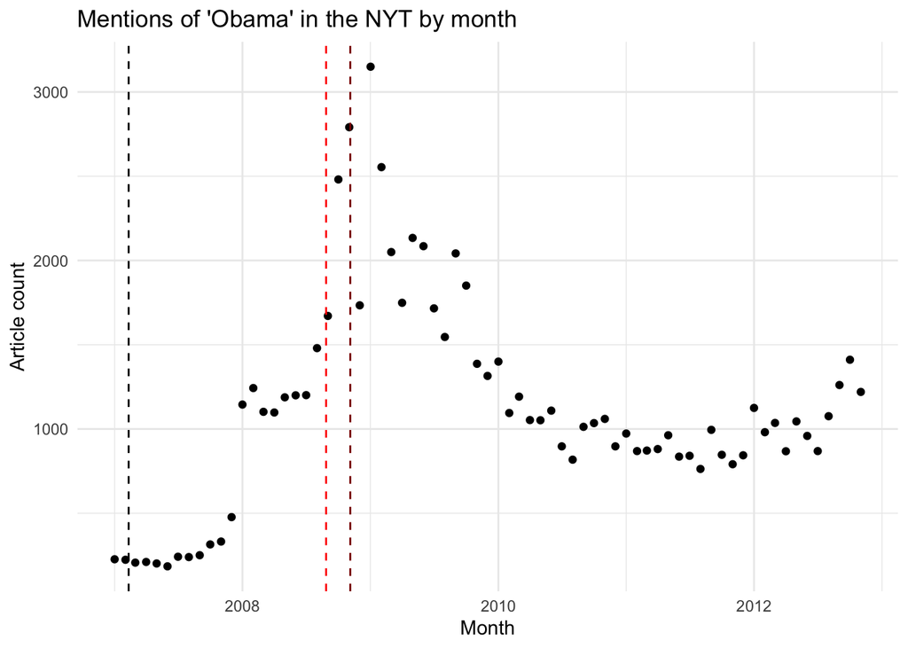

```r
ggplot(counts, aes(x = date, y = count)) +
  geom_point() +
  labs(title = "Mentions of 'Obama' in the NYT by month",
       x = "Month",
       y = "Article count") +
  geom_vline(xintercept = as.numeric(as.Date("2007/02/10")), linetype = "dashed") +
  geom_vline(xintercept = as.numeric(as.Date("2008/08/27")), linetype = "dashed", color = "red") +
  geom_vline(xintercept = as.numeric(as.Date("2008/11/04")), linetype = "dashed", color = "darkred") +
  theme_minimal()
```

### Archive API

Lastly, let us look at the Archive API which allows to download all materials for a given month. In the public version of the API, articles do not contain full texts, but usually headlines and very often at least one of abstract, snippet, and/or lead lead paragraphs The structure of the URL/endpoint can be found on https://developer.nytimes.com/docs/archive-product/1/overview. For example, the correct URL to request all articles September 2008 would be https://api.nytimes.com/svc/archive/v1/2008/9.json?api-key=yourkey. We will use the `sprintf` function from last week to create this URL for July 1855 as an example:

```r
exemplary_archive_url <- sprintf("https://api.nytimes.com/svc/archive/v1/%g/%g.json?api-key=%s", 1855, 7, apikey)
exemplary_archive_url
```

```
## [1] "https://api.nytimes.com/svc/archive/v1/1855/7.json?api-key=ng5PgWgqPoCqorzNRS8cwPPz2KAo1D7S"
```

Now we can run the associated query:

```r
r <- GET(exemplary_archive_url)
r
```

```
## Response [https://api.nytimes.com/svc/archive/v1/1855/7.json?api-key=ng5PgWgqPoCqorzNRS8cwPPz2KAo1D7S]
##   Date: 2025-03-23 15:44
##   Status: 200
##   Content-Type: application/json; charset=UTF-8
##   Size: 1.5 MB
```

The main data for this month can be obtained with the key “docs” within “response”. We can transform this information into a dataframe with:

```r
json_as_text <- content(r, "text")
json <- fromJSON(json_as_text)
df <- json$response$docs %>% as_tibble()
df
```

```
## # A tibble: 1,622 × 18
##    abstract          web_url snippet lead_paragraph print_page source multimedia
##    <chr>             <chr>   <chr>   <chr>          <chr>      <chr>  <list>
##  1 ""                https:… ""      ""             1          The N… <list [0]>
##  2 ""                https:… ""      ""             6          The N… <list [0]>
##  3 ""                https:… ""      ""             8          The N… <list [0]>
##  4 "In another part… https:… ""      ""             4          The N… <list [0]>
##  5 "Our city was vi… https:… ""      ""             8          The N… <list [0]>
##  6 "The season of h… https:… ""      ""             1          The N… <list [0]>
##  7 ""                https:… ""      ""             1          The N… <list [0]>
##  8 ""                https:… ""      ""             6          The N… <list [0]>
##  9 ""                https:… ""      ""             3          The N… <list [0]>
## 10 "To the Editor o… https:… ""      ""             2          The N… <list [0]>
## # ℹ 1,612 more rows
## # ℹ 11 more variables: headline <df[,7]>, keywords <list>, pub_date <chr>,
## #   document_type <chr>, news_desk <chr>, section_name <chr>, byline <df[,3]>,
## #   type_of_material <chr>, `_id` <chr>, word_count <int>, uri <chr>
```